# Midterm

## Question 7

Linear models were calculated to determine the relationship between the mRNA and protein mean differences.

For sample 143, the relationship was a significant negative relationship such that for any increase in the mean difference in mRNA there would be a decrease in the mean difference in protein. Histogram and Shapiro test demonstrate that the residuals are again distributed normally. Qq plot indicates that the residuals display a linear relationship with a few outliers that may influence the overall model fit. For both residuals vs. fitted and scale-location plots, the points are not well distributed across the plot and may indicate a problem with the model fit with sets of points gathering toward one end of the plot, but they generally appear to show a linear relationship. Two outliers are in common to these two plots: NP176 and NP1600. The residuals vs leverage plot demonstrates that the outliers identified in the other two plots are high value residuals but have low leverage which tells us they may not have much influence on the overall model after all. However gene NP1600 has a bit higher leverage and is really close to being outside Cook’s distance, so may be worth checking out.

ANOVA analyses of the model indicate that the model is a good fit and confirms the relationship between mRNA and protein expression differences in sample 143.

For sample 159, the relationship was a significant positive relationship such that for any increase in the mean difference in mRNA there would be an increase in the mean difference in protein. Histogram and Shapiro test demonstrate that the residuals are again distributed normally. Qq plot indicates that the residuals display a linear relationship with a few outliers that may influence the overall model fit. For both residuals vs. fitted and scale-location plots, the points are not well distributed across the plot and may indicate a problem with the model fit with sets of points gathering toward one end of the plot, but they generally appear to show a linear relationship. Three outliers are in common to these two plots: NP1809 and NP1822. and NP1600. The residuals vs leverage plot demonstrates that the outliers identified in the other two plots are high value residuals but have low leverage which tells us they may not have much influence on the overall model after all. However gene NP1600 again has a bit higher leverage and is really close to being outside Cook’s distance, so may be worth checking out.

ANOVA analyses of the model indicate that the model is a good fit and confirms the relationship between mRNA and protein expression differences in sample 159.

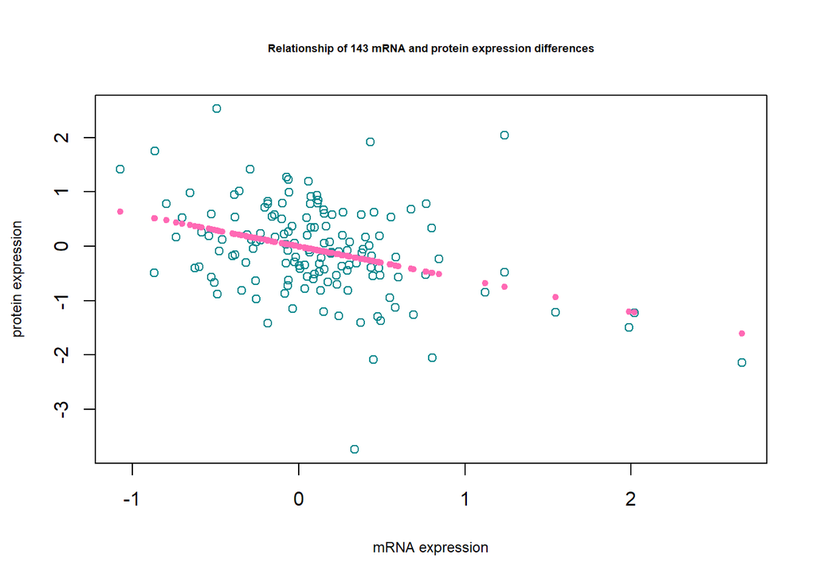

```r
lm.143<-lm(pr.diff.143~rna.diff.143)
lm.159<-lm(pr.diff.159~rna.diff.159)
plot(rna.diff.143,pr.diff.143,xlab="mRNA expression",ylab="protein expression",main="Relationship of 143 mRNA and protein expression differences",col="turquoise4",cex.lab=.75,cex.main=.55,pch=1)
points(rna.diff.143[!is.na(pr.diff.143)],predict(lm.143),col="hotpink",pch=20)
```

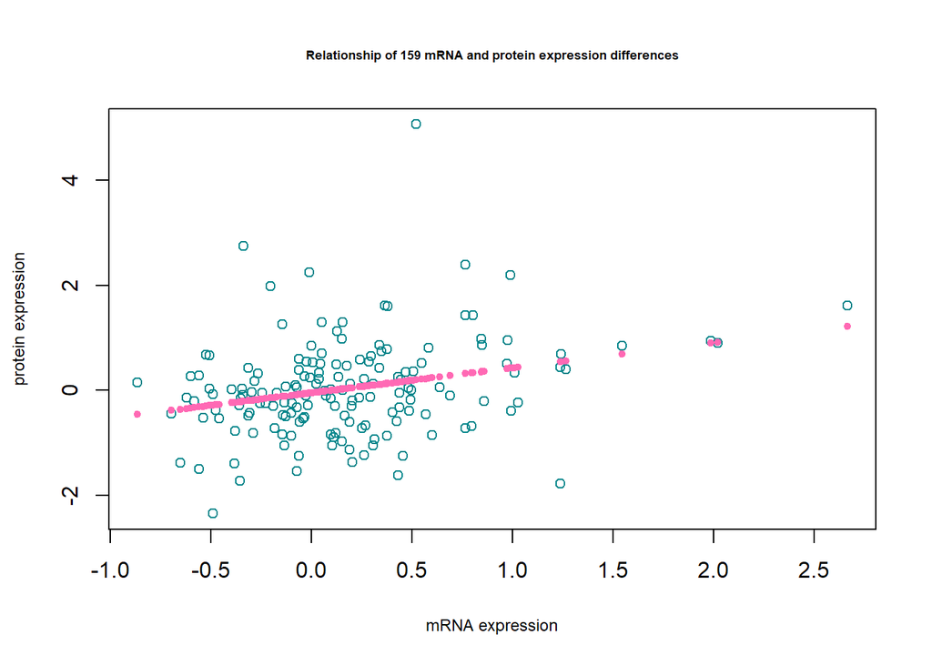

```r
plot(rna.diff.159,pr.diff.159,xlab="mRNA expression",ylab="protein expression",main="Relationship of 159 mRNA and protein expression differences",col="turquoise4",cex.lab=.75,cex.main=.55,pch=1)
points(rna.diff.159[!is.na(pr.diff.159)],predict(lm.159),col="hotpink",pch=20)
```

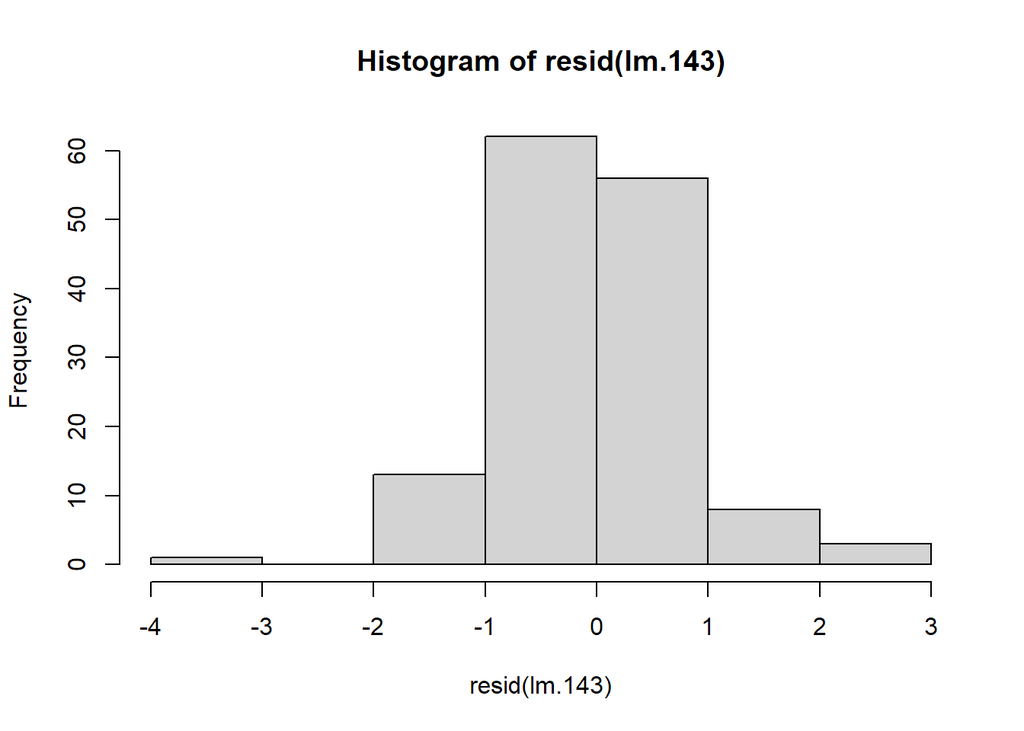

```r
hist(resid(lm.143))
```

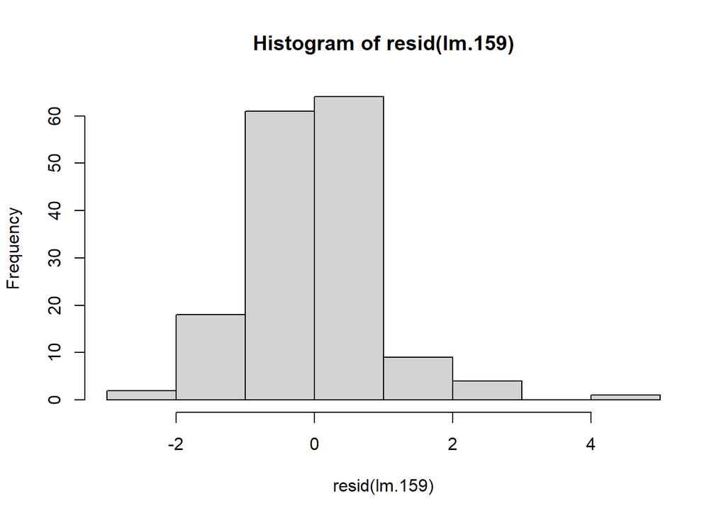

```r
hist(resid(lm.159))
```

```r
par(mfrow=c(2,2))
shapiro.test(resid(lm.143))$p.value
```

```
## [1] 0.0007797902
```

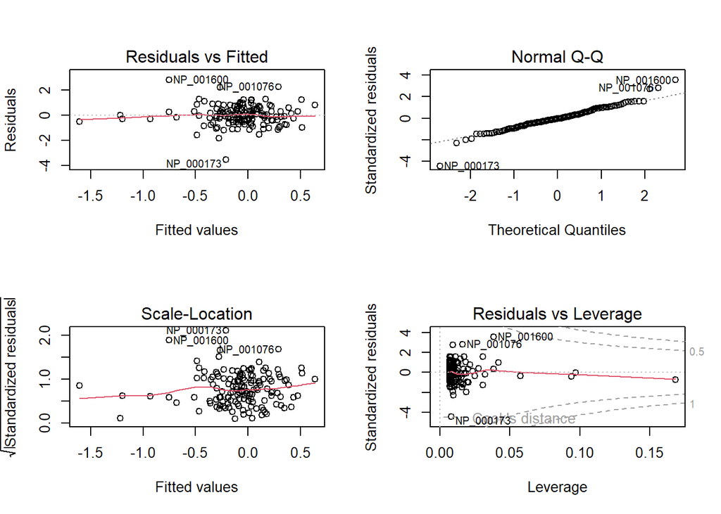

```r
plot(lm.143)
```

```r
anova(lm.143)
```

```
## Analysis of Variance Table
##
## Response: pr.diff.143
##               Df Sum Sq Mean Sq F value    Pr(>F)
## rna.diff.143   1 14.608 14.6081  22.777 4.497e-06 ***
## Residuals    141 90.431  0.6414
## ---
## Signif. codes:  0 '***' 0.001 '**' 0.01 '*' 0.05 '.' 0.1 ' ' 1
```

```r
shapiro.test(resid(lm.159))$p.value
```

```
## [1] 3.15311e-07
```

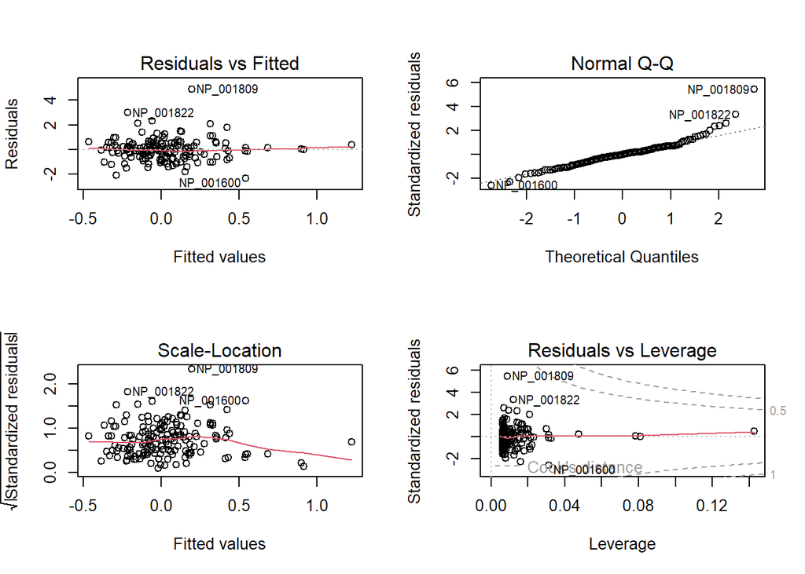

```r
plot(lm.159)
```

```r
anova(lm.159)
```

```
## Analysis of Variance Table
##
## Response: pr.diff.159
##               Df  Sum Sq Mean Sq F value    Pr(>F)
## rna.diff.159   1  10.372 10.3719  12.794 0.0004627 ***
## Residuals    157 127.281  0.8107
## ---
## Signif. codes:  0 '***' 0.001 '**' 0.01 '*' 0.05 '.' 0.1 ' ' 1
```

## Question 8

```r
m.143.eq<-matrix(0,nrow=nrow(r.143),ncol=4)
colnames(m.143.eq)<-c("rna.pval","pr.pval","r.anova","p.anova")
rownames(m.143.eq)<-rownames(r.143)
m.159.eq<-matrix(0,nrow=nrow(r.159),ncol=4)
colnames(m.159.eq)<-c("rna.pval","pr.pval","r.anova","p.anova")
rownames(m.159.eq)<-rownames(r.159)
count.143.rna<-0
count.143.pr<-0
count.159.rna<-0
count.159.pr<-0
for (i in 1:nrow(r.143)){
  p.rna.143<-t.test(r.143[i,3:8],r.143[i,9:14],var.equal=T,conf.level=.99)
  m.143.eq[i,1]<-p.rna.143$p.value
  if (p.rna.143$p.value<0.01){count.143.rna<-count.143.rna+1}
  p.pr.143<-t.test(r.143[i,15:17],r.143[i,18:20],var.equal=T,conf.level=.99)
  m.143.eq[i,2]<-p.pr.143$p.value
  if (p.pr.143$p.value<.01){count.143.pr<-count.143.pr+1}
}

for (i in 1:nrow(r.159)){
  p.rna.159<-t.test(r.159[i,3:8],r.159[i,9:14],var.equal=T,conf.level=.99)
  m.159.eq[i,1]<-p.rna.159$p.value
  if (p.rna.159$p.value<0.01){count.159.rna<-count.159.rna+1}
  p.pr.159<-t.test(r.159[i,15:17],r.159[i,18:20],var.equal=T,conf.level=.99)
  m.159.eq[i,2]<-p.pr.159$p.value
  if (p.pr.159$p.value<.01){count.159.pr<-count.159.pr+1}
  }
count.143.rna
```

```
## [1] 28
```

```r
count.143.pr
```

```
## [1] 8
```

```r
count.159.rna
```

```
## [1] 29
```

```r
count.143.pr
```

```
## [1] 8
```

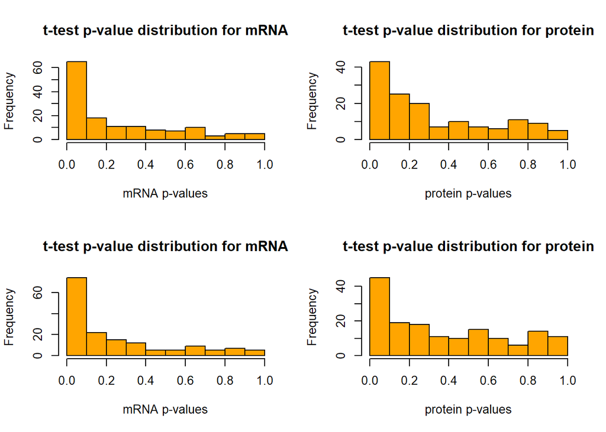

```r
par(mfrow=c(2,2))
hist(m.143.eq[,"rna.pval"],col="orange",xlab="mRNA p-values",main="t-test p-value distribution for mRNA")
hist(m.143.eq[,"pr.pval"],col="orange",xlab="protein p-values",main="t-test p-value distribution for protein")
hist(m.159.eq[,"rna.pval"],col="orange",xlab="mRNA p-values",main="t-test p-value distribution for mRNA")
hist(m.159.eq[,"pr.pval"],col="orange",xlab="protein p-values",main="t-test p-value distribution for protein")
```

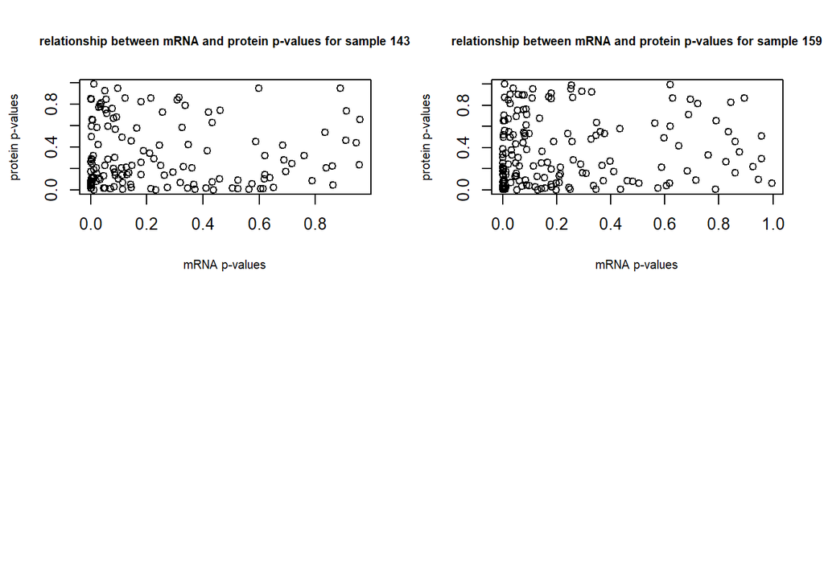

```r
plot(m.143.eq[,"rna.pval"],m.143.eq[,"pr.pval"],xlab="mRNA p-values",ylab="protein p-values",main="relationship between mRNA and protein p-values for sample 143",cex.main=.75,cex.lab=.75)
plot(m.159.eq[,"rna.pval"],m.159.eq[,"pr.pval"],xlab="mRNA p-values",ylab="protein p-values",main="relationship between mRNA and protein p-values for sample 159",cex.main=.75,cex.lab=.75)
```